LAB 1: Introduction to R and RStudio

BIO3782: Biologist's Toolkit (Dalhousie University)

# Lab mechanics (how to work through the labs of this course)

## Work flow in a typical Lab

[figure not shown]

In most labs, you will be required to read along the *Lab manual* and copy-paste code from the *lab manual* into *RStudio* to run it. This will create output in the form of numbers, graphs, maps, etc. Every once in a while, you will need to answer questions, which are written inside orange boxes like the one below. The questions need to be answered in the corresponding Brightspace *LAB quiz*. So, you will be jumping back and forth between the *Lab manual*, *RStudio* and the Brightspace *LAB quiz* throughout the lab.

Lets do a test question...

Sample question: Can you see THIS question in your Brightspace **LAB quiz?**

# Where is my code?

Data, code and the results produced by the code can be stored in many places, including:

1. **"the cloud"** (e.g. BrightSpace, your OneDrive, GitHub, a website, etc)
2. Your "physical" computer (like the computer that you are working on at this moment). Additionally, within your computer, data and code can be stored:
   - in the **hard-drive**,
   - in **memory** and
   - on the **screen**

[figure not shown]

Note that:

- **Computers** can ONLY see and work with code and data stored in **memory**
- **Humans** can ONLY see code and data shown on the **screen**
- When turning your computer off, code/data in both the **memory** and the **screen** are lost forever! Therefore, make sure that you save your work on your **hard-drive** or **the cloud**, before turning your computer off.

We will see below how to move code (and data) between all these storage areas (i.e. memory, hard-drive, screen, cloud). keeping track of where is your code/data stored, is one of the most common sources of errors during coding.

# R

[figure not shown]

['R'](https://www.r-project.org) is the most commonly used programming language among biologists today, primarily due to its [object-oriented](https://en.wikipedia.org/wiki/Object-oriented_programming) syntax and its powerful statistical and graphics capabilities. `R` was preinstalled in all Lab computers; however, if you want to follow along in your own laptop, you can install R directly from https://www.r-project.org

Note that when you installed `R`, a lot of code was copied from **"The Cloud"** into your **hard-drive**, in a location that we will call "the R Directory". The actual location of "the R Directory" is not important to us in this course. However, if you are curious and try to find it, just make sure that you **DO NOT** move, delete or add anything within "the R Directory"! You can break R's proper functioning.

# RStudio

[figure not shown]

`RStudio` is a free "Integrated Development Environment" (IDE) especially designed to work with R. `RStudio` was also pre-installed in all Lab computers; however, if you want to follow along in your own laptop, you can install `RStudio` directly from https://rstudio.com/

- To open `RStudio`, search in the taskbar for "RStudio", the program looks as follows:

[figure not shown]

Note that when you open `RStudio`, behind the scenes a bunch of code was loaded into **memory** from "the R Directory" (i.e. **hard-drive**).

The `RStudio` screen is divided in multiple panels. We will review the most important panels next.

## R's "Console"

[figure not shown]

```r
print('hello world!')
```

```
[1] "hello world!"
```

After you typed:

print('hello world!')

What got displayed on the screen?

You can also use R's console as a simple calculator.

```r
14 + 9
```

23

## RStudio's Help panel (and mini introduction to functions)

In the code above (i.e. `print('hello world!')`), we used the function `print()`. We will do a whole chapter on **functions** later. However, since we will use a few functions before we get to the functions chapter (like the `print()` function), I need to give you a mini introduction to functions now.

Most of the "fancy" work done in R is done through functions (e.g. calculate means, standard deviations, print stuff, etc). Most of them follow the generic nomeclature `FunctionName(Input)`. However, in some case you can give additional "arguments" that tell the function additional instructions on what to do with the input, in this case the generic nomeclature is `FunctionName(Input, Arguments)`.

The instruction manual of every function in R is accessible via the **Help panel**. To access it simple chick on the help tab; and to use it simply type the name of the function in the search bar within the Help panel.

[figure not shown]

## RStudio's "Editor"

[figure not shown]

[figure not shown]

```r
print('Hello world!')
```

```
[1] "Hello world!"
```

## Running you code

There are many ways to run the code you wrote in the editor. They require you clicking one the "run" buttons (see below) or using keyboard shortcuts.

[figure not shown]

### Executing a Single Line

To execute the line of source code where the cursor currently resides you press the Ctrl+Enter key (or use the Run toolbar button).

After executing the line of code, RStudio automatically advances the cursor to the next line. This enables you to single-step through a sequence of lines.

### Executing Multiple Lines

There are three ways to execute multiple lines from within the editor:

- Select the lines and press the Ctrl+Enter key (or use the Run toolbar button); or
- After executing a selection of code, use the Re-Run Previous Region command (or its associated toolbar button) to run the same selection again. Note that changes to the selection including additional, removal, and modification of lines will be reflected in this subsequent run of the selection.
- To run the entire document, press the Ctrl+Shift+Enter key (or use the Source toolbar button).

When you click the "run" button, RStudio automatically loads the code from the **Screen** (i.e. the Editor) into **memory** for execution.

Try running your code with all the buttons and keyboard shortcuts explained above.

After you write some code in the **Editor**, what happens when you click the **"source"** button?

## RStudio's "Working Directory"

The *working directory* is the location in your computer where RStudio is reading and writing files. If you click on the **Files** tab, you likely will be viewing the *working directory* and its contents. Also, within the **Files** tab, you can click on the `More` button to "Set the working directory" or "Go to the Working Directory".

[figure not shown]

The location displayed in the **Files** tab is not always the working directory. Therefore, the best way to get the working directory, use the `getwd()` function, see task below.

```r
getwd()
```

'C:/Users/Diego/Documents/6.Biologist\'s Toolkit/bitbucket/biol3782/week1'

- Did you see get the working directory?
- Did it match the location shown in the *Files* tab.

When you are working on a lab that requires ancillary data files or ancillary R code files, you need to make sure these files are in the *working directory*. You can download them directly to the *working directory*, or you can change the *working directory* to be folder where you downloaded your files.

### Change the "Working directory"

To change the *working directory*, you can:

- (1) go to the **Files** tab, (2) navigate to the folder that you want to make your new *working directory*, (3) click on the "More" button, and (4) select *Set As Working Directory*

[figure not shown]

You are starting to work on a lab that requires 2 ancillary data files and 3 ancillary R code files. You download all these files from BrightSpace into you Laptop. Which of the following describes best what happened to the data/code?

You are starting to work on a lab that requires 2 ancillary data files and 3 ancillary R script files. **Where** in your laptop do you have to put these files?

## Saving you code

To save your file to your hard-drive, simply click the "Save" button on the Editor (it looks like a floppy disk). You can name your file anything you want, but the extension will be automatically set as `.R`, which is the default extension for R files.

After you write some code in the *Editor*, clicking the "save" button technically transfers code from the **Screen** (i.e. the Editor) into a file in your **hard-drive**.

Save the R script file you created earlier. Name it hello_world.R

After you write some code in the **Editor**, what happens when you click the **"save"** button?

### Real-life Example: Downloading real-time data from an oceanographic buoy in Oregon

To explain the **Plots** and **Environment** panels in RStudio, it is required that we load some data and make a plot. I thought this would be a nice opportunity to do some real-life data mining and visualization. Let's download data from a bouy in Oregon. USA.

There is an autonomous buoy in the Columbia River (Oregon, USA) that broadcasts real-time ocean data via the following server: http://columbia.loboviz.com/

| LOBO Buoy | Columbia River (Oregon, USA) |
| --- | --- |

The following code connects to the buoy's server, downloads data, and makes a simple plot. **Note that A LOT gets done with just 3 lines of code.** This is the magic of "coding"!

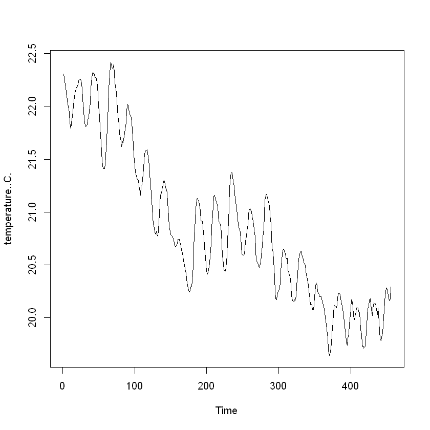

```r
# Define buoy's URL
bouyURL <- "http://columbia.loboviz.com/cgi-data/nph-data.cgi?x=date&y=temperature&min_date=20180820&max_date=20180907&node=32&data_format=text"

# Read data directly from buoy
data <- read.csv(bouyURL, sep = "\t", skip = 2)

# Do quick plot
plot.ts(data[2])
```

In this simple graph, the time x-axis is in not displayed as dates, but instead as "record number". Therefore we do not know if this time-series spans a few weeks or a few decades. However, we can probably deduce that the time span by looking at the y-axis. If the time-series span a few decades, you should see high temperatures of around 25 °C (maximum in the summer) and low temperatures around 5 or 10 °C (minimum in the winter). We do not see that range in the y-axis. Therefore, I think the time-series spans only a few weeks in late summer or early fall, because the temperature starts high (approx. 22 °C) and decrease a couple of degrees (~20 °C) over the span of the series. While Oregon is not a cold as Halifax, the water surface in the Columbia River should decrease in winter to just 5 or 10 °C, which we do not see in the plot. The high frequency variability (the up and down "wiggles" in temperature) is likely due to day-night temperature fluctuations in air temperature, or ebb-flood tide fluctuations. **All that from 3 lines of code!**

## RStudio's "Plots" panel

After you ran buoy.R, you will see the plot above in your RStudio's "Plots" panel (see below).

[figure not shown]

## RStudio's "Environment" panel

After you ran buoy.R, you will see the variables you created (i.e. `bouyURL` and `data`) in the "Environment panel" (see below).

[figure not shown]

This finishes our mini-tutorial to RStudio. Now it is time to start learning R.

# Comments and statements

- **Comments** are lines of text meant to be read ONLY by humans (i.e. the computer ignores these lines). Comments usually contain annotations and additional information to make easier to understand the code to the programmer. **Comments** are preceded by a **#** (hashtag)
- A **Statement** is a line of text read by the computer. This is "the code". A statement contains instructions for the computer to do a simple task.

Take a look to the sequence of comments and statements below:

```r
# This is a Comment because it is preceded by a # (hashtag)
x <- 5

# Lets print our variables to screen
print(x) # Note that comments can be written after a statement (but not before)
```

```
[1] 5
```

Above...

- The first line is a **comment**
- The second line is a **statement** assigning the value of `x` to be 5 (see "Variables" section below for more on this)
- Then there is a blank line. Blank lines are ignored by R (they exist to space the code and make it easier to read).
- The fourth line is a **comment**
- The fifth line is a **statement** asking R to print-to-screen the value of `x` to screen. After the statement, there is another comment

If you copy-paste the code above to the *RStudio's Editor* and click [run], it will print a `5` to the console.

Once `x = 5` has been executed, the value of `x` will be stored "in memory" until you turn off R, until you delete `x`, or until you update `x` with a different value.

## "Commenting out" code

The beauty of: Control + Shift + c

In RStudio, you can comment many lines at once by selecting the lines that you want to "comment out" and then click `Ctr` + `Shift` + `c`. This will insert a `#` at the beginning of all the selected lines. Note that you can do the reverse (i.e. **"uncomment code"**) by selecting several lines beginning with a `#` and again click `Ctr` + `Shift` + `c`.

Note that **"commenting out"** code is very useful during code development or testing, when you want to "disable" a few lines of code while you run tests or diagnostics; then, at a later time, you can "enable" (i.e. uncomment) your code without ever having to delete or re-write your code.

In the file that you created above (i.e. buoy.R). Select all lines and click `Ctr` + `Shift` + `c`.

- What happened to your code?

Select all lines again and click `Ctr` + `Shift` + `c` a second time.

- What happened to your code?

# Functions and their arguments

# Variables

[figure not shown]

A **Variable** is a user-defined label that can be used to name anything. I like to think "Variables" as **stickers** that you can glue to anything to give it a name. In the photo above, the "Variable **Name**" is what you wrote on the sticker (in this case, "Sugar") and the "Variable **Value**" is whatever you glued your sticker to (in this case, a 1 gr sugar cube).

In R, the way to create variables is with `<-`, `->` and `=`. See examples below:

```r
x <- 5 # Example 1

5 -> x # Example 2

x = 5  # Example 3
```

The convention of using the "arrow" symbols (i.e. `<-` and `->`) comes from the precursor of R, the S Programming Language). I personally prefer using `=` because `<-` requires you to type two characters (one needing the "shift" key); also the majority of other languages (e.g. Python, C++, etc.) use `=`. However, note that `=` only declares the variable in the current workspace (more on this later).

Either way, by far `<-` is the most used way to create variables by the R community, so we'll stick with this in this course.

In generic terms, the proper **nomenclature** to "declare" a variable is as follows:

VariableName <- VariableValue

Lets do a variable:

```r
x <- 5
```

Even though it looks like nothing happened, when you clicked [Enter], R create the new variable `x` in memory and assigned the value `5` to it. You can see the new variable `x`, and its value `5`, in the **Environment panel**. Alternatively, you can type the "Variable **Name**" in the to get the "Variable **Value**":

```r
x
```

5

Lets do another variable:

```r
y <- 3000

y
```

3000

Above, we bundled two steps in one entry: (1) we create the variable `y` with the value `3000`, and (2) we display the value of `y` to screen.

Lets do two more:

```r
a = 0

a

my_cute_variable <- 35

my_cute_variable
```

0

35

While you can name your variables anything you want, it is a good practice to choose variable names that describe what is stored within the variable. `Temperature` is better than `col1`, `number_eggs` is better than `e`, `TransectDensity` is better than `td`.

Take a look at the code you wrote in your file "bouy.R" (or see below).  
#Define buoy's URL  
bouyURL = "http://columbia.loboviz.com/cgi-data/nph-data.cgi?  
x=date&y=temperature&min_date=20180820&max_date=20180907&node=32&data_format=text"  
#Read data directly from buoy  
data = read.csv(bouyURL, sep = "\t", skip = 2)  
#Do quick plot  
plot.ts(data[2])  
Which of the following are **variables**?

## Check "Variables" loaded in memory

As we saw above, you can use RStudio's *Environment panel* to see what **variables** are currently loaded into **memory**, and well as their values.

[figure not shown]

You can also see a list of what **variables** are currently loaded into **memory** by executing the function `ls()` on RStudio's **console**:

```r
ls()
```

1. 'a'

3. 'bouyURL'

6. 'data'

8. 'my_cute_variable'

9. 'x'

10. 'y'

## Overwriting "Variables" values

When you create a **Variable**, you assign a Variable **Value** to it. However, you can change its Variable **Value** at anytime simply by assigning to it a different value (kinda' "overwriting" or "updating" its value). See below:

```r
x <- 4 # Assign value of 4 to variable "a"
print(x) # Check the value of "a"

# Lets change the value of "a"
x <- 2986 # Assign value 4
print(x) # Check again the value of "a"
```

```
[1] 4
[1] 2986
```

## Deleting "Variables"

### Deleting ONE variable

- To remove one variable, use the `rm()` function:

```r
a <- 4 # Make variable "a"
ls() # Check which variables exist in memory
```

1. 'a'

2. 'b'

3. 'bouyURL'

4. 'cssFile'

5. 'd'

6. 'data'

7. 'm'

8. 'my_cute_variable'

9. 'x'

10. 'y'

```r
rm(a) # Remove variable "a"
ls() # Check again which variables exist in memory
```

1. 'b'

2. 'bouyURL'

3. 'cssFile'

4. 'd'

5. 'data'

6. 'm'

7. 'my_cute_variable'

8. 'x'

9. 'y'

- Create a variable in RStudio... make the Variable **Name** `X` and the Variable **Value** `1000`.
- Check the that your new variable in displayed in the **Environment Panel**
- Use the `ls()` function to double-check that your new variable `X` is indeed present in **memory**
- Use the `rm()` command to remove `X`
- Verify that `X` is no longer in the **Environment Panel**
- Use the `ls()` function to double-check that the variable `X` is indeed not present in **memory**

### Deleting ALL variables

```r
ls() # Check which variables exist in memory
```

1. 'b'

2. 'bouyURL'

3. 'cssFile'

4. 'd'

5. 'data'

6. 'm'

7. 'my_cute_variable'

8. 'x'

9. 'y'

```r
rm(list = ls()) # Remove ALL variables

ls() # Check again which variables exist in memory
```

In R, what function is used to delete **one** variable?

In R, what statement is used to delete **ALL** variables in your environment?

# Basic data types

I mentioned earlier that R is an object-oriented language, where everything is an object. The "basic data types" are the simplest and most basic kinds of objects. All your data must be represented with one of these data types. Each data type behaves under different rules, thus it is important to always be aware of what data type each statement is working with. Below are some of the most common data types used in R:

- **double** or **numeric**: `2`, `15.5` (these are numbers allowed to have decimals)
- **integer**: `2L` (these are "round" numbers; the L tells R to store this as an integer)
- **character**: `"a"`, `"2"`, `"hello"` (these are letters)
- **logical**: `TRUE` or `FALSE`

You can use the `typeof()` function to query any variable to see what data type are they made of.

Lets dive a bit deeper into each different basic data type.

## Double (or numeric)

**Double (or numeric)** objects are numbers that are allowed to have a decimal point.

```r
x <- 4.67

typeof(x)
```

'double'

## Integers

**Integers** are "round" numbers (i.e. no decimal point). Note that you have to add an `L` at the end to specify the number is an integer. If you do not ad an L, R will think it is a **double** with .0 as a decimal.

```r
y <- 4L

typeof(y)
```

'integer'

## Character

**Characters** are letters. Note that you need to wrap the content of the string within quotes to tell R they are a character

```r
a <- "hello" # Example 1
b <- "2.3"   # Example 2

typeof(a)
typeof(b)
```

'character'

'character'

Note that even though `2.3` is a number, because we declared it with quotes (i.e. `"2.3"`), it will be treated by R as "letters". Therefore, you won't be able to do math with "2.3".

## Logical

Logicals can only have one of two values `TRUE` or `FALSE`. They are used to represent "true or false" statements.

```r
x <- FALSE

typeof(x)
```

'logical'

What data type is the following:  
324.91

What data type is the following:  
"the house is green"

What data type is the following:  
87572

If you execute the following line in Python...  
a = 32  
Then, what is "**32**"?

If you execute the following line in Python...  
a = 32  
Then, what is "**a**"?

# R Operators

Now that you know how to do `numeric`, `integer`, `character` and `logical` elements, you can do arithmetic, relational and logical operations. Below is a "cheat-sheet" of all the operators in R:

| Operator | Description |
| --- | --- |
|  | **## Arithmetic Operators ##** |
| + | Addition |
| - | Subtraction |
| * | Multiplication |
| / | Division |
| ^ | Exponent |
| %% | Modulus (Remainder from division) |
| %/% | Integer Division |
|  | **## Relational Operators ##** |
| < | Less than |
| > | Greater than |
| <= | Less than or equal to |
| >= | Greater than or equal to |
| == | Equal to |
| != | Not equal to |
|  | **## Logical Operators ##** |
| ! | Logical NOT |
| & | Element-wise logical AND |
| && | Logical AND |
| \| | Element-wise logical OR |
| \|\| | Logical OR |
|  | **## Assignment Operators ##** |
| <-, <<-, = | Leftwards assignment |
| ->, ->> | Rightwards assignment |

We won't dive in all of the operators at this point, but here are few examples:

```r
7 * 2
```

14

```r
x <- 8 - 3

x
```

5

```r
2^3
```

8

```r
7 > 2
```

TRUE

```r
9 >= 18
```

FALSE

# Data Structures (i.e. "Container" objects)

[figure not shown]

We mentioned that everything in R is an object, and that the "Basic Data Types" are the simplest type of objects. **"Data Structures"** are also objects, however a bit more complicated. **"Data Structures"** are designed to contain groups of other objects... thus, I like to call them **"Container"** objects.

In the photo above (i.e. jar of sugar cubes), the "Variable **Name**" is what you wrote on the sticker (in this case, "Sugar"), the "Variable **Value**" is whatever you glued your sticker to (in this case, a jar with 28 one-gram sugar cubes). The jar is a **"Container"** object and each of the sugar cubes is a different object, each with its own "Basic Data Type" and value.

The main **"Data Structures"** that we will discuss here are:

- Vector
- Matrix
- List
- Data Frame
- Factors

You can use the function `class()` to query the type of "Data Structure" of a variable, for example:

- `class(x)` will return `matrix`, if `x` is a **Matrix** Data Structure
- `class(x)` will return `list`, if `x` is a **List** Data Structure
- `class(x)` will return `data.frame`, if `x` is a **Data Frame** Data Structure
- `class(x)` will return `factor`, if `x` is a **Factor** Data Structure
- **Vectors** are the odd one here. `class(x)` will return the **Basic Data Type** of the elements within `x`, if `x` is a **Vector** Data Structure (see examples below).

## Vector

A vector is a collection of elements of **the same "Basic Data Type"** (i.e. `numeric`, `integer`, `character`, or `logical`). You can think of a "vector" as **one single column** in a spread-sheet. Technically, vectors can be either (1) **atomic vectors** (i.e. all elements of the same "Basic Data Type"), or (2) **lists** (i.e. elements can be of different types). However, the term “vector” most commonly refers to the "atomic vectors" and "list vectors" are referred simply as "lists", which we will discuss in a section below.

Vectors are particularly well suited to do matrix algebra.

To make a vector, use the "concatenate" function, `c`. Note: concatenate = to link objects together in a chain or series.

```r
x <- c(5, 2, 7, 4)

x

class(x)
```

1. 5

2. 2

3. 7

4. 4

'numeric'

Note that `class(x)` returned `'numeric'` because ALL the elements within `x` are of **Numeric** Basic Data Type.

```r
x <- c("a", "b", "c", "d")

x

class(x)
```

1. 'a'

2. 'b'

3. 'c'

4. 'd'

'character'

Note that `class(x)` returned `'character'` because ALL the elements within `x` are of **Character** Basic Data Type.

In the example below, lets insert a 'numeric' element among a bunch of 'character' elements to see what happens:

```r
x <- c("a", "b", 7, "d")

x

class(x)
```

1. 'a'

2. 'b'

3. '7'

4. 'd'

'character'

Note that R changed the "number" `7` for a "character" `'7'`. Thus `class(x)` returned `'character'` because ALL the elements within `x` are of **Character** Basic Data Type

## Matrix

**Matrices** are an extension of vectors. They are simply a vector with dimensions of "number of rows" by "number of columns". As with vectors, the elements of a matrix must be of the same Data Type.

Just like vectors, matrices are particularly well suited to do matrix algebra.

To make a **Matrix**, use the function `matrix()`

```r
x <- matrix(c(1, 2, 3, 4, 5, 6, 7, 8, 9, 10, 11, 12), nrow=4, ncol=3)

x

class(x)
```

| 1 | 5 | 9 |
| --- | --- | --- |
| 2 | 6 | 10 |
| 3 | 7 | 11 |
| 4 | 8 | 12 |

'matrix'

## List

**Lists** are like a vector, but **without the restriction** of having their contents of a single Data Type. You can mix `numeric`, `integer`, `character`, and `logical` elements within a single **List**. Lists are sometimes called "generic vectors", because the elements of a list can be of any type of R object, even lists containing further lists. This property makes them fundamentally different from the atomic vectors that we discussed above.

A list is a special type of vector. Each element can be a different type.

To make a list, use the function `list()`

```r
x <- list(1L, "a", 4, 6.87, TRUE, "hello")

x

class(x)
```

1. 1

2. 'a'

3. 4

4. 6.87

5. TRUE

6. 'hello'

'list'

Below is an example of a list that contains another list. We'll insert the list created in the code above as the 3rd element of the list below, `y`:

```r
# Example of lists within a list
y <- list(4, "world", x, 3.67)

y

class(y)
```

1. 4

2. 'world'

3. 1. 1

   2. 'a'

   3. 4

   4. 6.87

   5. TRUE

   6. 'hello'

4. 3.67

'list'

## Data Frame

**Data frames** are a very important data type in R. It’s pretty much the *de facto* data structure for most tabular data and what we use in biology field and plotting in general. **Data frames** can be created by hand, but most commonly they are generated when importing spreadsheets from your hard-drive or the web.

Remember that a "matrix" is a special type of "vector" with multiple rows and columns? Well, similarly, a **Data Frame** is a special type of **list** with multiple rows and column, where every element of the list has same length (i.e. data frame is a “rectangular” list). Same as lists, the elements of a **Data frames** can be of any type of R object (i.e. `numeric`, `integer`, `character`, `logical`, lists and other Data Frames).

```r
x <- data.frame(id = 1:10, x = 11:20, y = 21:30)

x

class(x)
```

| id | x | y |
| --- | --- | --- |
| 1 | 11 | 21 |
| 2 | 12 | 22 |
| 3 | 13 | 23 |
| 4 | 14 | 24 |
| 5 | 15 | 25 |
| 6 | 16 | 26 |
| 7 | 17 | 27 |
| 8 | 18 | 28 |
| 9 | 19 | 29 |
| 10 | 20 | 30 |

'data.frame'

Consider the statement below:  
x <- data.frame(x = 1:20, y = 21:40)  
What is class, or Data Structure is **x**?

Consider the statement below:  
x <- matrix(c(1, 2, 3, 4), nrow=2, ncol=2)  
What is class, or Data Structure is **x**?

Consider the statement below:  
x <- list(1, 2, 3, 4)  
What is class, or Data Structure is **x**?

Consider the statement below:  
x <- c(1, 2, 3, 4)  
What is class, or Data Structure is **x**?

Which of the Data Structures below **MUST** have all of their elements be of the same Data Type?

Which of the Data Structures below **CAN** have their elements be of any type of R object, including multiple Data Types?

# Indexing

There are multiple ways to access or replace values inside data structures. The most common approach is to use “indexing”. This is also referred to as “slicing”.

Note that brackets `[ ]` are used for indexing, whereas parentheses `( )` are used to call a function.

## Navigating within a vectors and lists

Consider the following vector `x` and list `y`:

```r
x <- c(5, 2, 7, 4)

y <- list(6, "hello", FALSE, x, 3.67, "world", 8L)
```

To get the first element of vector `x`:

```r
x[1]
```

5

To get the second element of list `y`:

```r
y[2]
```

1. 'hello'

Elements within a **list** are also **lists!** To get to the contents inside a "list element" you need to use double brackets `[[ ]]`:

```r
y[2]
class(y[2])

y[[2]]
class(y[[2]])
```

1. 'hello'

'list'

'hello'

'character'

So, for example, `y[1] + y[5]` will return an error, because you cannot "add" two lists. To add the two values you need to do:

```r
y[[1]] + y[[5]]
```

9.67

To get a **range** of elements use the `:`. For example, to get the first 3 elements of vector `x`:

```r
x[1:3]
```

1. 5

2. 2

3. 7

To get the 5th, 6th and 7th elements of list `y`:

```r
y[5:7]
```

1. 3.67

2. 'world'

3. 8

To access a **list within list**, you have to first dive into the values of the first list, using double brackets `[[ ]]`:

```r
# Here is the list stored in element 3
y[4]

# Here is the 3rd element of the list stored inside element 3 of list 'y'
y[[4]][3]
```

1. 1. 5

   2. 2

   3. 7

   4. 4

7

If you need the last element of a vector or list, but don't know how long is the vector or list, use the function `length()`:

```r
# To retrieve the last element of x
x[length(x)]
```

4

```r
# To retrieve the last 3 elements of x
x[(length(x)-2):length(x)]
```

1. 2

2. 7

3. 4

**Logical Indexing** is used when you need to retrieve elements according to a logical expression. This only works with vectors and list that **ONLY** contain numeric or integer data types.

```r
x[x > 3]
```

1. 5

2. 7

3. 4

```r
x[x <= 4]
```

1. 2

2. 4

Given the following list L:  
L <- list(7L, "hello", 3.6, c(7, 5, 2), 9, "world")  
...which is represented visually with the diagram below,

[figure not shown]

How would you access the value highlighted in the red box?

Given the following list L:  
L <- list(7L, "hello", 3.6, c(7, 5, 2), 9, "world")  
...which is represented visually with the diagram below,

[figure not shown]

How would you access the values highlighted in the red box?

Given the following list L:  
L <- list(7L, "hello", 3.6, c(7, 5, 2), 9, "world")  
...which is represented visually with the diagram below,

[figure not shown]

How would you access the value highlighted in the red box?

Given the following list L:  
L <- list(7L, "hello", 3.6, c(7, 5, 2), 9, "world")  
...which is represented visually with the diagram below,

[figure not shown]

How would you access the value highlighted in the red box?

Given the following list L:  
L <- list(7L, "hello", 3.6, c(7, 5, 2), 9, "world")  
...which is represented visually with the diagram below,

[figure not shown]

How would you access the values highlighted in the red box?

## Navigating within Matrices

Consider the following matrix `m`:

```r
m <- matrix(c(1, 2, 3, 4, 5, 6, 7, 8, 9, 10, 11, 12), nrow=4, ncol=3)

m
```

| 1 | 5 | 9 |
| --- | --- | --- |
| 2 | 6 | 10 |
| 3 | 7 | 11 |
| 4 | 8 | 12 |

To get to a single number within the matrix, use a pair of indices where the **first index is the row number** and the **second index is the column number**:

```r
m[1,2]
```

5

Rather than using pairs, you can also get single index. You can think of this index as a “cell number”. Cells are numbered column-wise (i.e., first the rows in the first column, then the second column, etc.). Thus,

```r
m[6]
```

6

You can also get multiple values at once:

```r
m[1:2,2:3]
```

| 5 | 9 |
| --- | --- |
| 6 | 10 |

To get a whole **column**, use a coma **before** the column index. The statement below read *return all rows of column 1:

```r
m[, 1]
```

1. 1

2. 2

3. 3

4. 4

To get a whole **row**, use a coma **after** the row index: The statement below read *return row 1... all columns:

```r
m[1,]
```

1. 1

2. 5

3. 9

Getting a whole **row** or **column** from a matrix returns a `vector`:

```r
class(m)

class(m[, 1])
```

'matrix'

'numeric'

Given the following matrix m:  
m <- matrix(c(2,4,7,3,5,3,9,7,0,6,8,2),nrow=4, ncol=3)  
...which is represented visually with the diagram below,

[figure not shown]

How would you access the value highlighted in the red box?

Given the following matrix m:  
m <- matrix(c(2,4,7,3,5,3,9,7,0,6,8,2),nrow=4, ncol=3)  
...which is represented visually with the diagram below,

[figure not shown]

How would you access the values highlighted in the red box?

Given the following matrix m:  
m <- matrix(c(2,4,7,3,5,3,9,7,0,6,8,2),nrow=4, ncol=3)  
...which is represented visually with the diagram below,

[figure not shown]

How would you access the values highlighted in the red box?

Given the following matrix m:  
m <- matrix(c(2,4,7,3,5,3,9,7,0,6,8,2),nrow=4, ncol=3)  
...which is represented visually with the diagram below,

[figure not shown]

If you make a **new variable** with the values highlighted in the red box (using your answer to the question above)... ...what class or Data Structure will be asigned to your **new variable**?

## Navigating within Data Frames

Consider the following data frame `d`:

```r
d <- data.frame(id = 1:10, x = 11:20, y = 21:30)

d
```

| id | x | y |
| --- | --- | --- |
| 1 | 11 | 21 |
| 2 | 12 | 22 |
| 3 | 13 | 23 |
| 4 | 14 | 24 |
| 5 | 15 | 25 |
| 6 | 16 | 26 |
| 7 | 17 | 27 |
| 8 | 18 | 28 |
| 9 | 19 | 29 |
| 10 | 20 | 30 |

You can extract a column by column number:

```r
d[,2]
```

1. 11

2. 12

3. 13

4. 14

5. 15

6. 16

7. 17

8. 18

9. 19

10. 20

Here is an alternative way to address the column number in a data frame:

```r
d[2]
```

| x |
| --- |
| 11 |
| 12 |
| 13 |
| 14 |
| 15 |
| 16 |
| 17 |
| 18 |
| 19 |
| 20 |

Note that whereas `[2]` would be the second element in a matrix, it refers to the second *column* in a `data.frame`. This is because a `data.frame` is a special kind of list and not a special kind of matrix.

You can also use the column name to get the values of a column:

```r
d[,"x"]
```

1. 11

2. 12

3. 13

4. 14

5. 15

6. 16

7. 17

8. 18

9. 19

10. 20

In addition to `d[,"x"]` above, you can also use the `$` symbol.

Using the `$` symbol is a very common practice to slice a column of a `data.frame`:

```r
d$x
```

1. 11

2. 12

3. 13

4. 14

5. 15

6. 16

7. 17

8. 18

9. 19

10. 20

```r
d["x"]
```

| x |
| --- |
| 11 |
| 12 |
| 13 |
| 14 |
| 15 |
| 16 |
| 17 |
| 18 |
| 19 |
| 20 |

Note that both `d[,"x"]` and `d$x` return a `vector`. That is, the complexity of the `data.frame` structure was `dropped`. This does not happen when you do `d["x"]`, where the outputs remains a `data.frame`. Take a look:

```r
class(d[,"x"]) # This drops the data.frame and returns a vector
class(d$x)     # This drops the data.frame and returns a vector
class(d["x"])  # This preserves the data.frame
```

'integer'

'integer'

'data.frame'

Why should you care about this `drop` business? In many cases R functions want a specific data type, such as a `matrix` or `data.frame` and report an error if they get something else. One common situation is that you think you provide data of the right type, such as a `data.frame`, but that in fact you are providing a vector, because the structure dropped.

Either way, you can use `[ ]` with all three approaches to get to a specific value within a column:

```r
d[["x"]][2]
```

12

```r
d$x[2]
```

12

```r
d$x[2:4]
```

1. 12

2. 13

3. 14

Given the following Data Frame d:  
d <- data.frame(x=2:6, y=3:7, z=4:8)  
...which is represented visually with the diagram below,

[figure not shown]

How would you access the values highlighted in the red box?

Given the following Data Frame d:  
d <- data.frame(x=2:6, y=3:7, z=4:8)  
...which is represented visually with the diagram below,

[figure not shown]

Select all the choices that you could use to access the values highlighted in the red box?

Given the following Data Frame d:  
d <- data.frame(x=2:6, y=3:7, z=4:8)  
...which is represented visually with the diagram below,

[figure not shown]

How would you access the value highlighted in the red box?

Given the following Data Frame d:  
d <- data.frame(x=2:6, y=3:7, z=4:8)  
and given the following subset of d, created as follows:  
subset_d <- d[,"x"]  
What class or Data Structure would be subset_d?

Given the following Data Frame d:  
d <- data.frame(x=2:6, y=3:7, z=4:8)  
and given the following subset of d, created as follows:  
subset_d <- d$x  
What class or Data Structure would be subset_d?

Given the following Data Frame d:  
d <- data.frame(x=2:6, y=3:7, z=4:8)  
and given the following subset of d, created as follows:  
subset_d <- d["x"]  
What class or Data Structure would be subset_d?

Some parts of this lab where borrowed from:

- [Software Carpentry](https://software-carpentry.org/)
- [Data Carpentry](https://datacarpentry.org/)
- [Spatial Data Science with R](https://rspatial.org/)

This is the end of lab

Code below is for formatting of this lab. Do not alter!

```r
cssFile <- '../css/custom.css'
IRdisplay::display_html(readChar(cssFile, file.info(cssFile)$size))

IRdisplay::display_html("<style>.Q::before {counter-increment: question_num;
    content: 'QUESTION ' counter(question_num) ': '; white-space: pre; }.T::before {counter-increment: task_num;
    content: 'Task ' counter(task_num) ': ';</style>")
```